# CMPINF 2130 Summer 2021 - Week 08

correlation plots per group

Dr. Joseph P. Yurko

July 2021

## Load packages

```r
library(tidyverse)
library(corrr)
```

`corrr` is a package dedicated to working with, manipulating, and visualizing correlation matrices.

## Iris data

```r
iris_corrr <- iris %>%
  purrr::keep(is.numeric) %>%
  corrr::correlate()
```

```
##
## Correlation method: 'pearson'
## Missing treated using: 'pairwise.complete.obs'
```

Contrast this with the behavior from `cor()` function from base `R`.

```r
iris_cor_base <- iris %>%
  purrr::keep(is.numeric) %>%
  cor()
```

Display the correlation matrix from base R.

```r
iris_cor_base
```

```
##              Sepal.Length Sepal.Width Petal.Length Petal.Width
## Sepal.Length    1.0000000  -0.1175698    0.8717538   0.8179411
## Sepal.Width    -0.1175698   1.0000000   -0.4284401  -0.3661259
## Petal.Length    0.8717538  -0.4284401    1.0000000   0.9628654
## Petal.Width     0.8179411  -0.3661259    0.9628654   1.0000000
```

Display the `correlate()` correlation matrix.

```r
iris_corrr
```

```
## # A tibble: 4 x 5
##   term         Sepal.Length Sepal.Width Petal.Length Petal.Width
##   <chr>               <dbl>       <dbl>        <dbl>       <dbl>
## 1 Sepal.Length       NA          -0.118        0.872       0.818
## 2 Sepal.Width        -0.118      NA           -0.428      -0.366
## 3 Petal.Length        0.872      -0.428       NA           0.963
## 4 Petal.Width         0.818      -0.366        0.963      NA
```

Change the diagonal behavior.

```r
iris %>%
  purrr::keep(is.numeric) %>%
  correlate(diagonal = 1)
```

```
##
## Correlation method: 'pearson'
## Missing treated using: 'pairwise.complete.obs'
```

```
## # A tibble: 4 x 5
##   term         Sepal.Length Sepal.Width Petal.Length Petal.Width
##   <chr>               <dbl>       <dbl>        <dbl>       <dbl>
## 1 Sepal.Length        1          -0.118        0.872       0.818
## 2 Sepal.Width        -0.118       1           -0.428      -0.366
## 3 Petal.Length        0.872      -0.428        1           0.963
## 4 Petal.Width         0.818      -0.366        0.963       1
```

Visualize the correlation dataframe using `rplot()`.

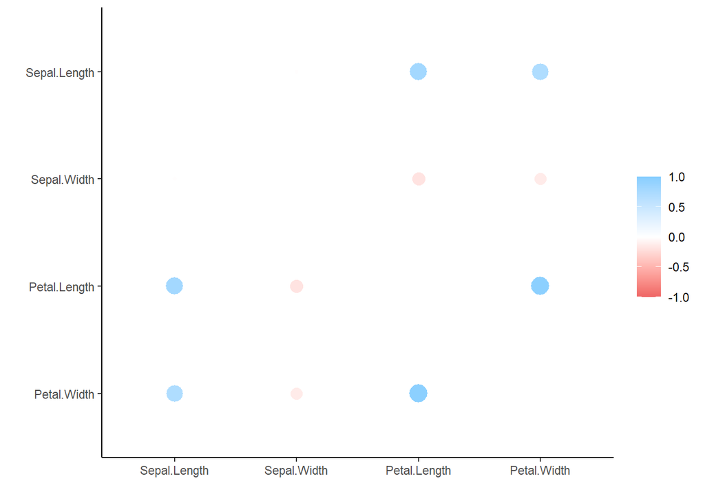

```r
iris_corrr %>% rplot()
```

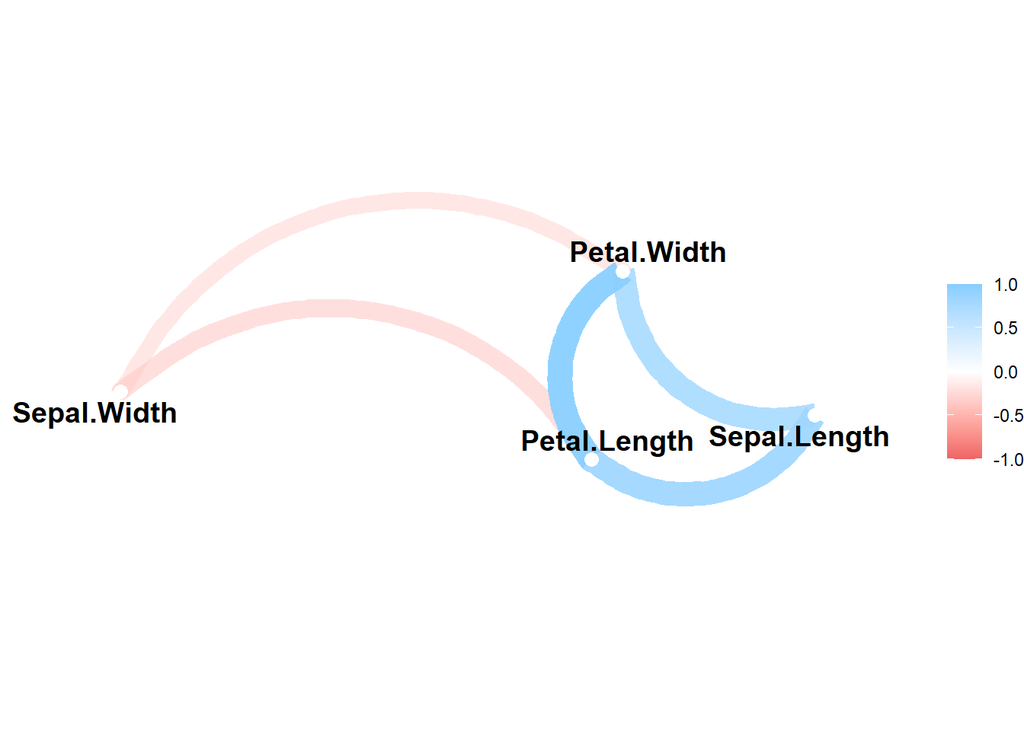

```r
iris_corrr %>% network_plot()
```

`corrr` also allows reshaping the correlation dataframe into a long-format.

```r
iris_corrr %>% stretch()
```

```
## # A tibble: 16 x 3
##    x            y                 r
##    <chr>        <chr>         <dbl>
##  1 Sepal.Length Sepal.Length NA
##  2 Sepal.Length Sepal.Width  -0.118
##  3 Sepal.Length Petal.Length  0.872
##  4 Sepal.Length Petal.Width   0.818
##  5 Sepal.Width  Sepal.Length -0.118
##  6 Sepal.Width  Sepal.Width  NA
##  7 Sepal.Width  Petal.Length -0.428
##  8 Sepal.Width  Petal.Width  -0.366
##  9 Petal.Length Sepal.Length  0.872
## 10 Petal.Length Sepal.Width  -0.428
## 11 Petal.Length Petal.Length NA
## 12 Petal.Length Petal.Width   0.963
## 13 Petal.Width  Sepal.Length  0.818
## 14 Petal.Width  Sepal.Width  -0.366
## 15 Petal.Width  Petal.Length  0.963
## 16 Petal.Width  Petal.Width  NA
```

The long-format is especially useful for working with grouped correlation dataframes. Let’s create the grouped correlation dataframe for each level of `Species`.

```r
iris %>%
  group_by(Species) %>%
  tidyr::nest() %>%
  mutate(cor_wf = purrr::map(data, correlate)) %>%
  mutate(cor_lf = purrr::map(cor_wf, stretch)) %>%
  select(Species, cor_lf) %>%
  tidyr::unnest(cor_lf)
```

```
##
## Correlation method: 'pearson'
## Missing treated using: 'pairwise.complete.obs'
##
##
## Correlation method: 'pearson'
## Missing treated using: 'pairwise.complete.obs'
##
##
## Correlation method: 'pearson'
## Missing treated using: 'pairwise.complete.obs'
```

```
## # A tibble: 48 x 4
## # Groups:   Species [3]
##    Species x            y                 r
##    <fct>   <chr>        <chr>         <dbl>
##  1 setosa  Sepal.Length Sepal.Length NA
##  2 setosa  Sepal.Length Sepal.Width   0.743
##  3 setosa  Sepal.Length Petal.Length  0.267
##  4 setosa  Sepal.Length Petal.Width   0.278
##  5 setosa  Sepal.Width  Sepal.Length  0.743
##  6 setosa  Sepal.Width  Sepal.Width  NA
##  7 setosa  Sepal.Width  Petal.Length  0.178
##  8 setosa  Sepal.Width  Petal.Width   0.233
##  9 setosa  Petal.Length Sepal.Length  0.267
## 10 setosa  Petal.Length Sepal.Width   0.178
## # ... with 38 more rows
```

We can now visualize the correlation coefficient with `ggplot2` using facets to display the levels of `Species`.

```
##
## Correlation method: 'pearson'
## Missing treated using: 'pairwise.complete.obs'
##
##
## Correlation method: 'pearson'
## Missing treated using: 'pairwise.complete.obs'
##
##
## Correlation method: 'pearson'
## Missing treated using: 'pairwise.complete.obs'
```

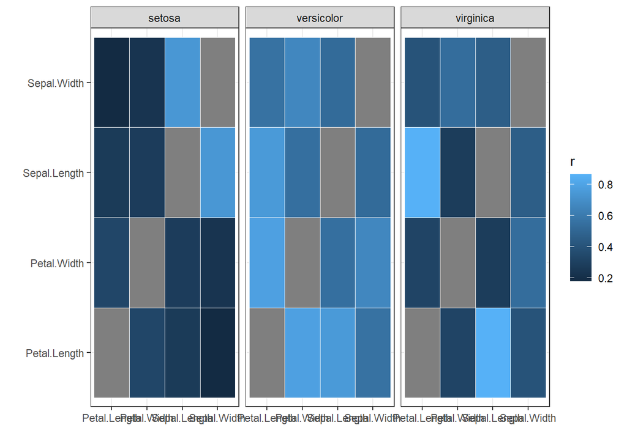

```r
iris %>%
  group_by(Species) %>%
  tidyr::nest() %>%
  mutate(cor_wf = purrr::map(data, correlate)) %>%
  mutate(cor_lf = purrr::map(cor_wf, stretch)) %>%
  select(Species, cor_lf) %>%
  tidyr::unnest(cor_lf) %>%
  ungroup() %>%
  ggplot(mapping = aes(x = x, y = y)) +
  geom_tile(mapping = aes(fill = r),
            color = 'white') +
  facet_wrap(~Species) +
  labs(x = '', y ='') +
  theme_bw()
```

Modify the correlation plot fill and legend.

```
##
## Correlation method: 'pearson'
## Missing treated using: 'pairwise.complete.obs'
##
##
## Correlation method: 'pearson'
## Missing treated using: 'pairwise.complete.obs'
##
##
## Correlation method: 'pearson'
## Missing treated using: 'pairwise.complete.obs'
```

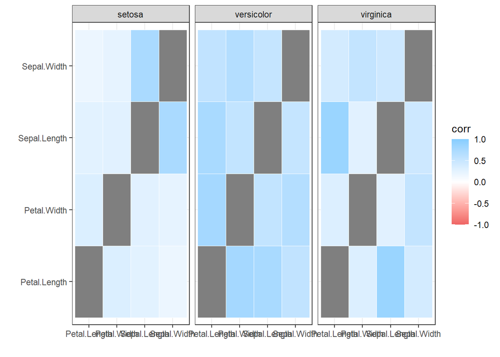

```r
iris %>%
  group_by(Species) %>%
  tidyr::nest() %>%
  mutate(cor_wf = purrr::map(data, correlate)) %>%
  mutate(cor_lf = purrr::map(cor_wf, stretch)) %>%
  select(Species, cor_lf) %>%
  tidyr::unnest(cor_lf) %>%
  ungroup() %>%
  ggplot(mapping = aes(x = x, y = y)) +
  geom_tile(mapping = aes(fill = r),
            color = 'white') +
  facet_wrap(~Species) +
  scale_fill_gradient2('corr',
                       low = 'indianred2',
                       mid = 'white',
                       high = 'skyblue1',
                       midpoint = 0,
                       limits = c(-1, 1)) +
  labs(x = '', y ='') +
  theme_bw()
```

Rotate the x-axis label text.

```
##
## Correlation method: 'pearson'
## Missing treated using: 'pairwise.complete.obs'
##
##
## Correlation method: 'pearson'
## Missing treated using: 'pairwise.complete.obs'
##
##
## Correlation method: 'pearson'
## Missing treated using: 'pairwise.complete.obs'
```

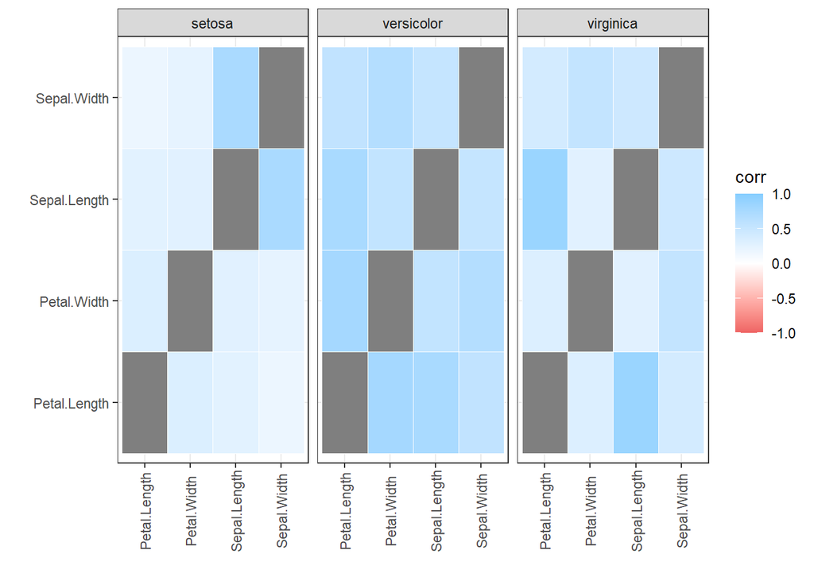

```r
iris %>%
  group_by(Species) %>%
  tidyr::nest() %>%
  mutate(cor_wf = purrr::map(data, correlate)) %>%
  mutate(cor_lf = purrr::map(cor_wf, stretch)) %>%
  select(Species, cor_lf) %>%
  tidyr::unnest(cor_lf) %>%
  ungroup() %>%
  ggplot(mapping = aes(x = x, y = y)) +
  geom_tile(mapping = aes(fill = r),
            color = 'white') +
  facet_wrap(~Species) +
  scale_fill_gradient2('corr',
                       low = 'indianred2',
                       mid = 'white',
                       high = 'skyblue1',
                       midpoint = 0,
                       limits = c(-1, 1)) +
  labs(x = '', y ='') +
  theme_bw() +
  theme(axis.text.x = element_text(angle=90, vjust=0.5))
```

Turn off or make the correlation function work “quietly”.

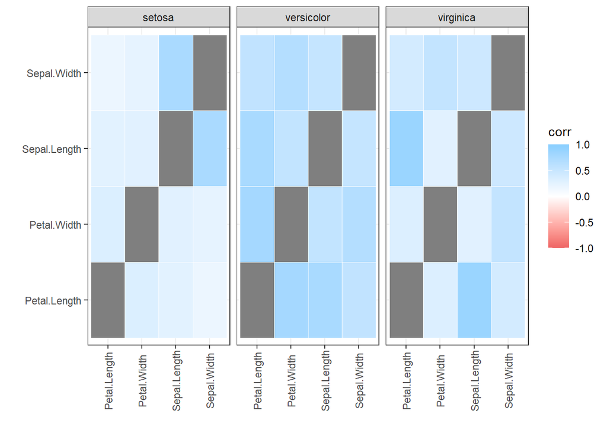

```r
iris %>%
  group_by(Species) %>%
  tidyr::nest() %>%
  mutate(cor_wf = purrr::map(data, correlate, quiet=TRUE)) %>%
  mutate(cor_lf = purrr::map(cor_wf, stretch)) %>%
  select(Species, cor_lf) %>%
  tidyr::unnest(cor_lf) %>%
  ungroup() %>%
  ggplot(mapping = aes(x = x, y = y)) +
  geom_tile(mapping = aes(fill = r),
            color = 'white') +
  facet_wrap(~Species) +
  scale_fill_gradient2('corr',
                       low = 'indianred2',
                       mid = 'white',
                       high = 'skyblue1',
                       midpoint = 0,
                       limits = c(-1, 1)) +
  labs(x = '', y ='') +
  theme_bw() +
  theme(axis.text.x = element_text(angle=90, vjust=0.5))
```

I like to dispaly the correlation coefficient as text or to annotate the plot.

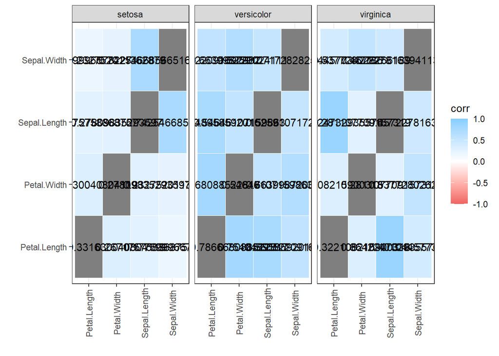

```r
iris %>%
  group_by(Species) %>%
  tidyr::nest() %>%
  mutate(cor_wf = purrr::map(data, correlate, quiet=TRUE)) %>%
  mutate(cor_lf = purrr::map(cor_wf, stretch)) %>%
  select(Species, cor_lf) %>%
  tidyr::unnest(cor_lf) %>%
  ungroup() %>%
  ggplot(mapping = aes(x = x, y = y)) +
  geom_tile(mapping = aes(fill = r),
            color = 'white') +
  geom_text(mapping = aes(label = r)) +
  facet_wrap(~Species) +
  scale_fill_gradient2('corr',
                       low = 'indianred2',
                       mid = 'white',
                       high = 'skyblue1',
                       midpoint = 0,
                       limits = c(-1, 1)) +
  labs(x = '', y ='') +
  theme_bw() +
  theme(axis.text.x = element_text(angle=90, vjust=0.5))
```

The `corrr` package has a helper function called `fashion()` to make the text display “pretty”. I prefer to use the base R `round()` function to round the value.

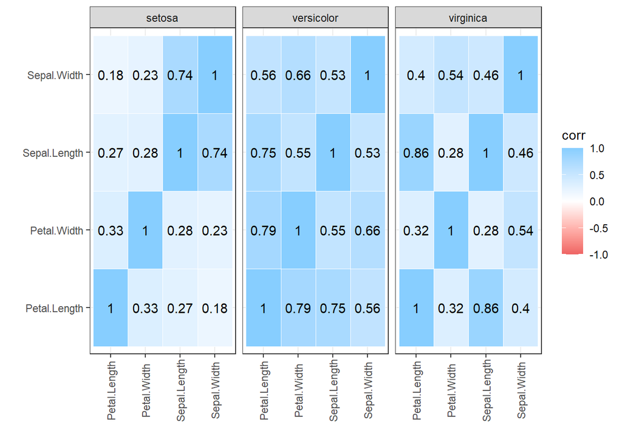

```r
iris %>%
  group_by(Species) %>%
  tidyr::nest() %>%
  mutate(cor_wf = purrr::map(data, correlate, quiet=TRUE, diagonal=1)) %>%
  mutate(cor_lf = purrr::map(cor_wf, stretch)) %>%
  select(Species, cor_lf) %>%
  tidyr::unnest(cor_lf) %>%
  ungroup() %>%
  ggplot(mapping = aes(x = x, y = y)) +
  geom_tile(mapping = aes(fill = r),
            color = 'white') +
  geom_text(mapping = aes(label = round(r, 2))) +
  facet_wrap(~Species) +
  scale_fill_gradient2('corr',
                       low = 'indianred2',
                       mid = 'white',
                       high = 'skyblue1',
                       midpoint = 0,
                       limits = c(-1, 1)) +
  labs(x = '', y ='') +
  theme_bw() +
  theme(axis.text.x = element_text(angle=90, vjust=0.5))
```

## Sonar data

Caclculate the correlation matrix for the continuous variables in `Sonar` and visualize as a network style graphic.

```r
data("Sonar", package = 'mlbench')
```

Check the dimensionality.

```r
Sonar %>% dim()
```

```
## [1] 208  61
```

Check the data types.

```r
Sonar %>% purrr::map_chr(class)
```

```
##        V1        V2        V3        V4        V5        V6        V7        V8
## "numeric" "numeric" "numeric" "numeric" "numeric" "numeric" "numeric" "numeric"
##        V9       V10       V11       V12       V13       V14       V15       V16
## "numeric" "numeric" "numeric" "numeric" "numeric" "numeric" "numeric" "numeric"
##       V17       V18       V19       V20       V21       V22       V23       V24
## "numeric" "numeric" "numeric" "numeric" "numeric" "numeric" "numeric" "numeric"
##       V25       V26       V27       V28       V29       V30       V31       V32
## "numeric" "numeric" "numeric" "numeric" "numeric" "numeric" "numeric" "numeric"
##       V33       V34       V35       V36       V37       V38       V39       V40
## "numeric" "numeric" "numeric" "numeric" "numeric" "numeric" "numeric" "numeric"
##       V41       V42       V43       V44       V45       V46       V47       V48
## "numeric" "numeric" "numeric" "numeric" "numeric" "numeric" "numeric" "numeric"
##       V49       V50       V51       V52       V53       V54       V55       V56
## "numeric" "numeric" "numeric" "numeric" "numeric" "numeric" "numeric" "numeric"
##       V57       V58       V59       V60     Class
## "numeric" "numeric" "numeric" "numeric"  "factor"
```

Visualize the network style correlation plot.

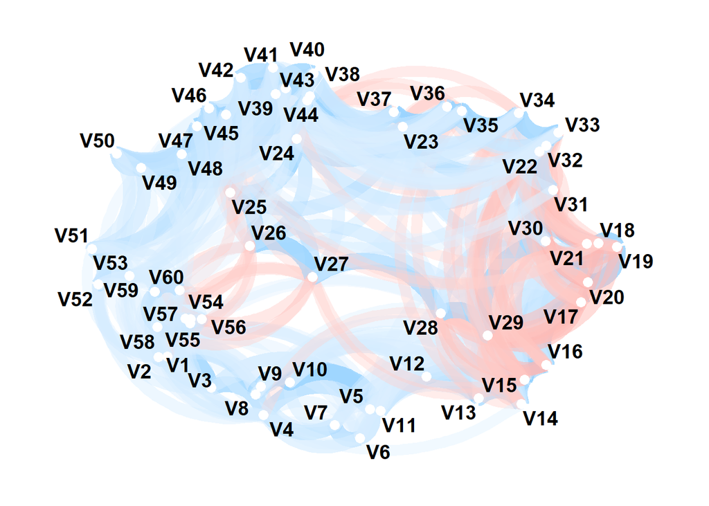

```r
Sonar %>%
  purrr::keep(is.numeric) %>%
  correlate(quiet=TRUE) %>%
  network_plot(legend = FALSE)
```

Lastly, let’s calculate the correlation matrix per group of `Class`.

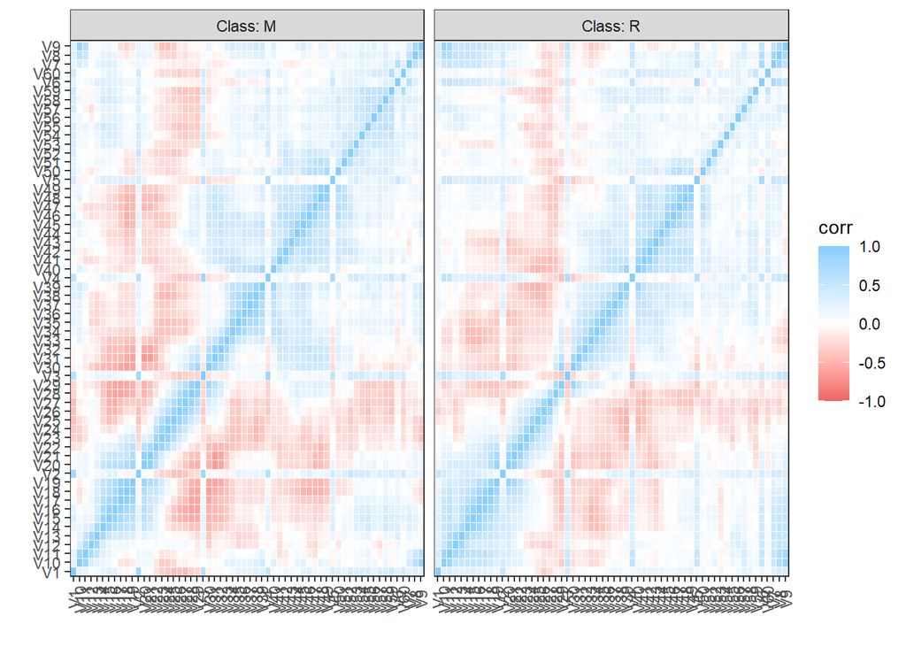

```r
Sonar %>%
  group_by(Class) %>%
  tidyr::nest() %>%
  mutate(cor_wf = purrr::map(data, correlate, quiet=TRUE, diagonal=1)) %>%
  mutate(cor_lf = purrr::map(cor_wf, stretch)) %>%
  select(Class, cor_lf) %>%
  tidyr::unnest(cor_lf) %>%
  ungroup() %>%
  ggplot(mapping = aes(x = x, y = y)) +
  geom_tile(mapping = aes(fill = r), color='white') +
  facet_wrap(~Class, labeller = "label_both") +
  scale_fill_gradient2('corr',
                       low = 'indianred2',
                       mid='white',
                       high='skyblue1',
                       midpoint=0,
                       limits = c(-1,1)) +
  labs(x='',y='') +
  theme_bw() +
  theme(axis.text.x = element_text(angle=90, vjust=0.5))
```

Use string manipulation from the `stringr` package to extract the number for the variable.

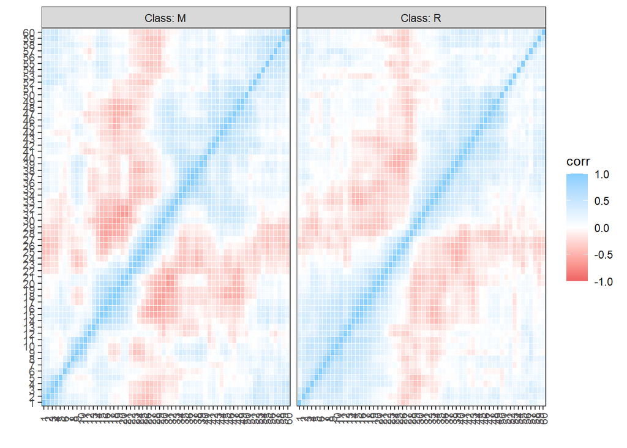

```r
Sonar %>%
  group_by(Class) %>%
  tidyr::nest() %>%
  mutate(cor_wf = purrr::map(data, correlate, quiet=TRUE, diagonal=1)) %>%
  mutate(cor_lf = purrr::map(cor_wf, stretch)) %>%
  select(Class, cor_lf) %>%
  tidyr::unnest(cor_lf) %>%
  ungroup() %>%
  mutate(x_number = stringr::str_extract(x, "\\d+"),
         y_number = stringr::str_extract(y, '\\d+')) %>%
  mutate(x_number = as.numeric(x_number),
         y_number = as.numeric(y_number)) %>%
  ggplot(mapping = aes(x = as.factor(x_number), y = as.factor(y_number))) +
  geom_tile(mapping = aes(fill = r), color='white') +
  facet_wrap(~Class, labeller = "label_both") +
  scale_fill_gradient2('corr',
                       low = 'indianred2',
                       mid='white',
                       high='skyblue1',
                       midpoint=0,
                       limits = c(-1,1)) +
  labs(x='',y='') +
  theme_bw() +
  theme(axis.text.x = element_text(angle=90, vjust=0.5))
```